# ETC5521 Diving Deeper into Data Exploration: Assignment 2

Author

Chang Heng Hsieh

Published

September 1, 2025

## 🛠️ Exercises

```r
# Load necessary libraries
# install.packages(c("tidyverse", "janitor", "lubridate", "readxl", "here", "validate", "knitr"))
library(tidyverse)
library(readr)
library(janitor)
library(lubridate)
library(readxl)
library(here)
library(validate)
library(kableExtra)


# Import water quality data and metadata
# Specify col_types from the start to handle known formatting issues
yarra_wq <- read_excel(
  here("data/yarra_wq.xls"),
  col_types = c("numeric", "text", "text", "text", "numeric",
                "text", "numeric", "text", "numeric", "text")
) %>%
  clean_names()

SW_Metadata <- read_csv(here("data/SW Metadata.csv"))%>%
  clean_names()

# Inspect data structure
glimpse(yarra_wq)
```

[output not shown]

## Question 1 : Conduct an IDA

**Data Screening for checking types of variables:**

```r
# Parse datetime column robustly
yarra_wq_process <- yarra_wq %>%
  mutate(
    datetime_text = str_trim(datetime, side = "both"),
    datetime = coalesce(
      excel_numeric_to_date(as.numeric(datetime_text)),
      ymd_hms(datetime_text, quiet = TRUE)
    )
  )

# Check missing values
missing_summary <- yarra_wq_process %>%
  summarise(
    missing_site_id = sum(is.na(site_id)),
    missing_datetime = sum(is.na(datetime)),
    missing_parameter = sum(is.na(parameter)),
    missing_value = sum(is.na(value))
  )

kable(missing_summary,
      caption = "Summary of Missing Values After Datetime Parsing",
      booktabs = TRUE) %>%
  kable_styling(bootstrap_options = c("striped", "hover"),
                full_width = FALSE)
```

Summary of Missing Values After Datetime Parsing

| missing_site_id | missing_datetime | missing_parameter | missing_value |
| --- | --- | --- | --- |
| 0 | 0 | 0 | 0 |

The table shows the missing values in datetime are resolved after parsing datetime.

```r
# Remove duplicates, keeping first occurrence
yarra_wq_process <- yarra_wq_process %>%
  distinct(site_id, datetime, parameter, .keep_all = TRUE)

# Remove unreasonable values as value must be positive
# pH range must be 0-14
yarra_wq_clean <- yarra_wq_process %>%
  filter( value >= 0,
          !(parameter == "pH" & (value < 0 | value > 14))
  ) %>%
  # Create the required date feature columns
  mutate(
    site_id = as.factor(site_id),
    date = as_date(datetime),
    year = year(datetime),
    month = month(datetime, label = TRUE),
    day = day(datetime),
    weekday = wday(datetime, label = TRUE),
    hour = hour(datetime)
  ) %>%
  select(
    site_id, name, date, year, month, day, weekday, hour,
    parameter, value, unit_of_measurement, quality, resolution
  )

# Inspect cleaned data
glimpse(yarra_wq_clean)
```

```
Rows: 16,257
Columns: 13
$ site_id             <fct> 229108, 229108, 229108, 229108…
$ name                <chr> "YARRA DS MCMAHONS", "YARRA DS…
$ date                <date> 1962-06-15, 1962-06-16, 1962-…
$ year                <dbl> 1962, 1962, 1962, 1962, 1962, …
$ month               <ord> 六月, 六月, 六月, 六月, 六月, 六月, 六月, 六月…
$ day                 <int> 15, 16, 17, 18, 19, 20, 21, 22…
$ weekday             <ord> 週五, 週六, 週日, 週一, 週二, 週三, 週四, 週五…
$ hour                <int> 0, 0, 0, 0, 0, 0, 0, 0, 0, 0, …
$ parameter           <chr> "Streamflow (mean daily)", "St…
$ value               <dbl> 80, 95, 227, 223, 136, 252, 20…
$ unit_of_measurement <chr> "ML/day", "ML/day", "ML/day", …
$ quality             <dbl> 1, 1, 1, 1, 1, 1, 1, 1, 1, 1, …
$ resolution          <chr> "Raw Data", "Raw Data", "Raw D…
```

```r
# Write the cleaned data to a new file as required
write_csv(yarra_wq_clean, here("data", "yarra_wq_clean.csv"))
```

To compare water quality between the 1990s and recent years, we identify sites and parameters with sufficient measurements in both periods (1990–1999 and 2015–present).

```r
# Filter out the 1990s and recent years periods.
data_1990s <- yarra_wq_clean %>%
  filter(year >= 1990 & year < 2000) %>%
  count(site_id, name, parameter, name = "count_1990s")

data_recent <- yarra_wq_clean %>%
  filter(year >= 2015) %>%
  count(site_id, name, parameter, name = "count_recent")

sufficient_data <- inner_join(
  data_1990s, data_recent,
  by = c("site_id", "name", "parameter"))

kable(sufficient_data,
      caption =
        "Sites and Parameters with Sufficient Measurements in 1990s and Recent Years",
      booktabs = TRUE,
      col.names = c(
        "Site ID", "Site Name", "Parameter", "Count (1990s)", "Count (Recent)")) %>%
  kable_styling(bootstrap_options = c("striped", "hover"),
                full_width = FALSE)
```

Table 1: Summary of sites and parameters with data in both the 1990s and recent years.

Sites and Parameters with Sufficient Measurements in 1990s and Recent Years

| Site ID | Site Name | Parameter | Count (1990s) | Count (Recent) |
| --- | --- | --- | --- | --- |
| 229143 | YARRA @ CHANDLER HWY | Nitrogen as Total Kjeldahl (TKN) | 32 | 2 |
| 229143 | YARRA @ CHANDLER HWY | Phosphorus (Total) | 32 | 2 |
| 229143 | YARRA @ CHANDLER HWY | Salinity as EC@25 | 46 | 149 |
| 229143 | YARRA @ CHANDLER HWY | Turbidity | 46 | 146 |
| 229143 | YARRA @ CHANDLER HWY | Water Temperature | 46 | 149 |
| 229143 | YARRA @ CHANDLER HWY | pH | 46 | 149 |

Table 1 shows that only `site_id 229143` (“YARRA @ CHANDLER HWY”) has consistent measurements in both periods for parameters like Salinity, Turbidity, Water Temperature, and pH. Nitrogen and Phosphorus have limited recent data, making them less suitable for robust comparison.

**Limitations**

The cleaned dataset (yarra_wq_clean.csv) is ready for further analysis, focusing on `site_id 229143` and the parameters Salinity, Turbidity, Water Temperature, and pH.

## Question 2: Exploratory Data Analysis (EDA)

### 1. Numerical Summaries

```r
# Filter for the specific site and the most viable parameters for comparison
# Create the period column for comparison
yarra_wq_compare <- yarra_wq_clean %>%
  filter(site_id == 229143,
         parameter %in% c("pH", "Salinity as EC@25", "Turbidity", "Water Temperature"))%>%
         mutate(period = case_when(
           year >= 1990 & year < 2000 ~ "1990s",
           year >= 2010 ~ "Recent"
         )) %>%
  filter(!is.na(period))

# Calculate summary statistics
numerical_summary <- yarra_wq_compare %>%
  group_by(parameter, period) %>%
  summarise(
    count = n(),
    mean = round(mean(value, na.rm = TRUE), 2),
    std_dev = round(sd(value, na.rm = TRUE), 2),
    median = round(median(value, na.rm = TRUE), 2),
    .groups = 'drop'
  ) %>%
  arrange(parameter, period)

kable(numerical_summary,
      caption = "Summary Statistics for Water Quality Parameters at Site 229143",
      booktabs = TRUE,
      col.names = c(
        "Parameter", "Period", "Count", "Mean", "Standard Deviation", "Median")) %>%
  kable_styling(bootstrap_options = c("striped", "hover"),
                full_width = FALSE)
```

Table 2: Numerical summary of water quality parameters at Chandler Highway, comparing the 1990s and recent years.

Summary Statistics for Water Quality Parameters at Site 229143

| Parameter | Period | Count | Mean | Standard Deviation | Median |
| --- | --- | --- | --- | --- | --- |
| Salinity as EC@25 | 1990s | 46 | 184.3 | 74.91 | 180.0 |
| Salinity as EC@25 | Recent | 149 | 194.4 | 107.81 | 180.0 |
| Turbidity | 1990s | 46 | 46.9 | 50.20 | 29.5 |
| Turbidity | Recent | 146 | 38.2 | 48.96 | 23.0 |
| Water Temperature | 1990s | 46 | 15.2 | 4.52 | 15.0 |
| Water Temperature | Recent | 149 | 17.1 | 5.15 | 18.1 |
| pH | 1990s | 46 | 6.6 | 1.48 | 6.9 |
| pH | Recent | 149 | 7.4 | 0.46 | 7.3 |

The summary in Table 2 shows that the water quality at Chandler Highway has changed in complex ways, not just declined. Some indicators have worsened, while others have actually improved.

Overall, we cannot say the water quality has simply declined. While the rising water temperature is a concern, other important measures like water clarity (lower turbidity) and pH stability have improved. The complaint from the Rakali organisation may only reflect one aspect of a more complicated situation.

### 2. Graphical Summaries

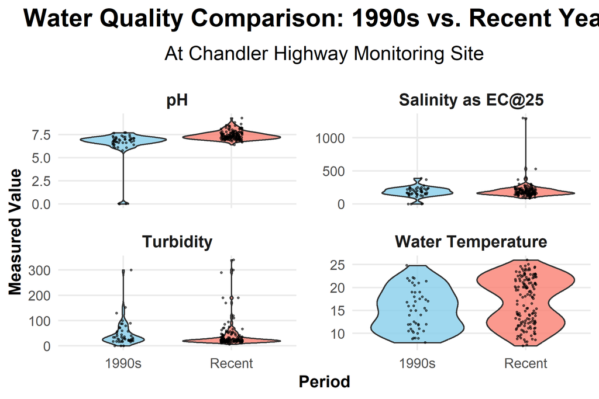

Figure 1: Distribution of water quality parameters at Chandler Highway, comparing the 1990s vs. recent years.

```r
# Create side-by-side plots for each parameter
ggplot(yarra_wq_compare, aes(x = period, y = value, fill = period)) +
  geom_violin(alpha = 0.8) +
  geom_jitter(width = 0.1, alpha = 0.5, size = 0.5) +
  scale_fill_manual(values = c("1990s" = "skyblue", "Recent" = "salmon")) +
  facet_wrap(~ parameter, scales = "free_y", ncol = 2) +
  labs(
    title = "Water Quality Comparison: 1990s vs. Recent Years",
    subtitle = "At Chandler Highway Monitoring Site",
    x = "Period",
    y = "Measured Value") +
  theme_minimal(base_size = 12) +
  theme(
    plot.title = element_text(size = 18, face = "bold", hjust = 0.5,
                              margin = margin(b = 10)),
    plot.subtitle = element_text(size = 14, hjust = 0.5, margin = margin(b = 15)),
    axis.title = element_text(size = 12, face = "bold"),
    axis.text = element_text(size = 10),
    strip.text = element_text(size = 12, face = "bold"),
    panel.spacing = unit(1, "lines"),
    panel.grid.minor = element_blank(),
    legend.position = "none"
  )
```

The violin plots in Figure 1 reveal a fundamental shift in the river’s state between the 1990s and recent years:

- **Negative Indicators:**

The `Water Temperature` distribution has unequivocally shifted to a warmer regime. Similarly, the wider shape of the `Salinity` violin for the recent period points to increased variability and instability.

- **Positive Indicators:**

**Exploring Parameter Relationships**

To add more depth, we can explore whether the relationships between parameters have changed over time.

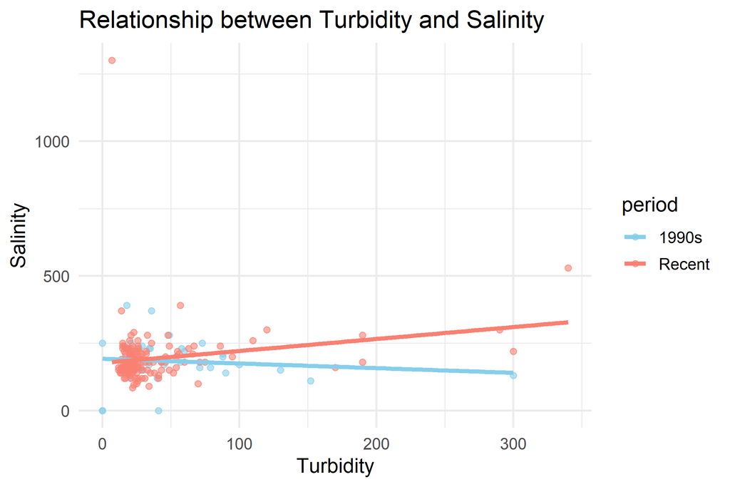

Figure 2: Relationship between Turbidity and Salinity, by period.

```r
# Reshape data to wide format for scatter plots
yarra_wq_wide <- yarra_wq_compare %>%
  mutate(parameter = case_when(
    parameter == "Salinity as EC@25" ~ "Salinity",
    parameter == "Water Temperature" ~ "Water_Temperature",
    TRUE ~ parameter
  )) %>%
  select(date, parameter, value, period) %>%
  pivot_wider(
    names_from = parameter,
    values_from = value,
    values_fn = mean
  ) %>%
  drop_na()

# Plot 1: Turbidity vs Salinity
ggplot(yarra_wq_wide, aes(x = Turbidity, y = Salinity, color = period)) +
  geom_point(alpha = 0.6) +
  geom_smooth(method = "lm", se = FALSE, linewidth = 1.2) +
  scale_color_manual(values = c("1990s" = "skyblue", "Recent" = "salmon")) +
  labs(
    title = "Relationship between Turbidity and Salinity",
    x = "Turbidity",
    y = "Salinity"
  ) +
  theme_minimal(base_size = 12)
```

The relationship between Turbidity and Salinity, shown in Figure 2, reveals a fundamental shift in the river’s response to runoff. In the 1990s, a weak negative correlation existed where higher turbidity was associated with lower salinity, suggesting a classic dilution effect from rainfall. However, in the recent period, this trend has reversed to a positive correlation. This change indicates that the impact of rainfall on water quality has evolved, possibly due to increased urbanization where runoff now carries a higher salt load into the river system.

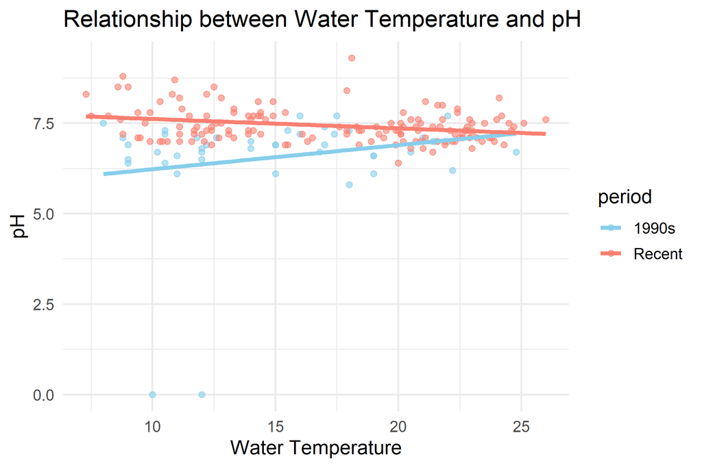

Figure 3: Relationship between Water Temperature and pH, by period.

```r
# Plot 2: Water Temperature vs pH
ggplot(yarra_wq_wide, aes(x = Water_Temperature, y = pH, color = period)) +
  geom_point(alpha = 0.6) +
  geom_smooth(method = "lm", se = FALSE, linewidth = 1.2) +
  scale_color_manual(values = c("1990s" = "skyblue", "Recent" = "salmon")) +
  labs(
    title = "Relationship between Water Temperature and pH",
    x = "Water Temperature",
    y = "pH"
  ) +
  theme_minimal(base_size = 12)
```

As illustrated in Figure 3, the relationship between water temperature and pH has fundamentally changed. In the 1990s, a clear positive correlation existed, indicating a reactive system where pH was sensitive to temperature changes. In the recent period, this relationship has disappeared, with the trend line becoming almost flat. This demonstrates that the river’s pH is now more stable and robust, and is no longer significantly influenced by temperature fluctuations, which suggests an improvement in chemical resilience.

## Question 3 : Check your findings

### 1. Testing the Change in the Water Temperature-pH Relationship

**Original Finding**: The scatter plot reveals a significant shift in the relationship between water temperature and pH. In the 1990s, a positive correlation existed, suggesting a system where pH was sensitive to temperature changes. In the recent period, this correlation has vanished, with the trend line becoming flat, indicating a more stable and buffered system.

**Null Hypothesis ($H_0$)**: There is no linear relationship between water temperature and pH within each period (slope = 0). Additionally, any observed difference in slopes between the 1990s and Recent periods is due to random variation, not a systematic change.

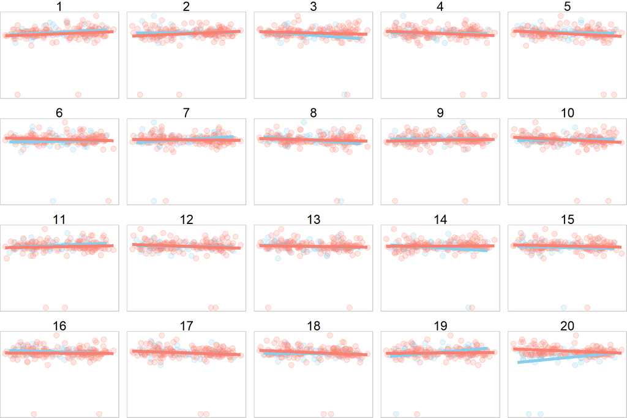

Figure 4: Relationship between Water Temperature and pH by period

```r
library(nullabor)
set.seed(123)

# Lineup Plot for Turbidity-Salinity
lineup(
    null_permute("pH"),
    yarra_wq_wide,
    n = 20
  )%>%
  ggplot(aes(x = Water_Temperature, y = pH, color = period)) +
  geom_point(alpha = 0.2) +
  geom_smooth(method = "lm", se = FALSE, linewidth = 1) +
  scale_color_manual(values = c("1990s" = "skyblue", "Recent" = "salmon")) +
  facet_wrap(~ .sample, ncol = 5) +
  theme_void() +
  theme(
    plot.title = element_text(hjust = 0.5, size = 16),
    panel.border = element_rect(colour = "grey80", fill = NA),
    legend.position = "none"
  )
```

```r
nullabor::pvisual(8, 10, 20)
```

```
     x simulated   binom
[1,] 8         0 1.6e-09
```

We can confidently **reject the null hypothesis** based on the lineup plot test that 8 out of 10 observers correctly identified the plot #20 as the most different from the null plots, which corresponds to a **p-value of 1.6e-09** under the null hypothesis of random guessing.

While the relationship between water temperature and pH remains weak, the data provides evidence for: (1) a detectable linear association between water temperature and pH that differs from pure random variation, and (2) systematic differences in this relationship between the 1990s and recent periods.

The finding from our EDA is statistically significant: the relationship between water temperature and pH has fundamentally changed over the decades. The shift from a temperature-sensitive system in the 1990s to a stable, temperature-independent system in recent years is a real and meaningful feature of the data.

### 2. Testing the Change in Water Temperature

**Original Finding**: Our EDA showed a clear and significant increase in Water Temperature in recent years.

**Null Hypothesis ($H_0$)**: The distribution of **Water Temperature `value`s is independent of the `period`(1990s vs. Recent)**. Any apparent difference between the two periods in our plot is simply due to random variation.

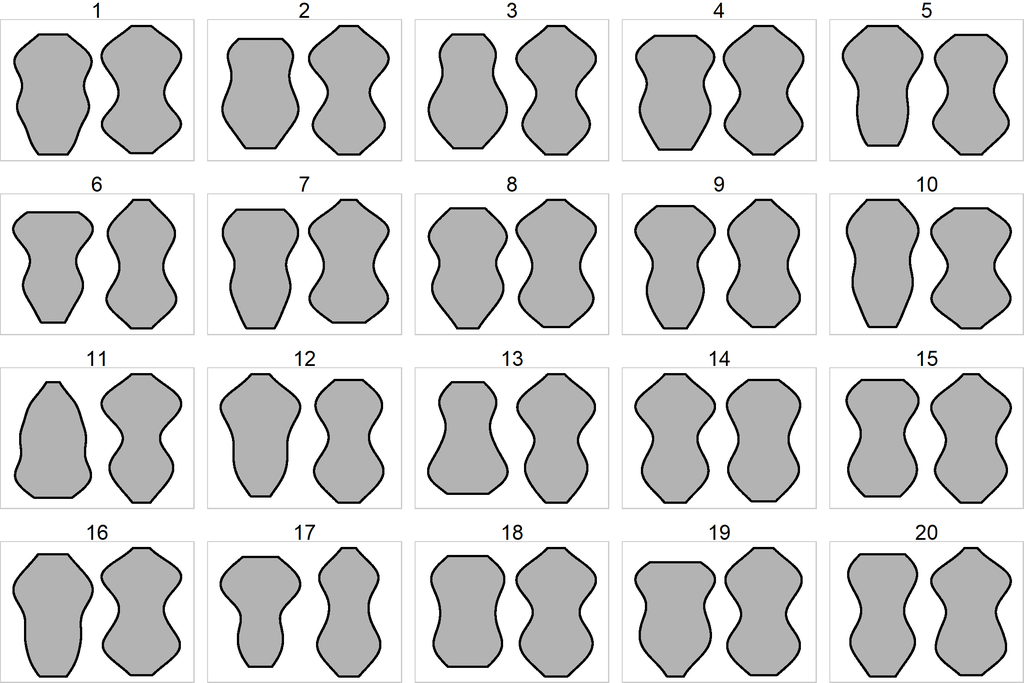

```r
# Lineup Plot for Temperature
set.seed(456)

temp_data <- yarra_wq_compare %>%
  filter(parameter == "Water Temperature")

lineup(
  method = null_permute("period"),
  true = temp_data,
  n = 20
) %>%
  ggplot(aes(x = period, y = value)) +
  geom_violin(fill = "gray70", color = "black") +
  facet_wrap(~ .sample, ncol = 5) +
  theme_void() +
  theme(
    plot.title = element_text(hjust = 0.5, size = 16),
    panel.border = element_rect(colour = "grey80", fill=NA))
```

```r
nullabor::pvisual(6, 10, 20)
```

```
     x simulated   binom
[1,] 6         0 2.8e-06
```

We can **reject the null hypothesis** based on the results of the lineup test. When the plot was presented to 10 independent observers, 6 correctly identified plot #11 as the one most different from the null plots, which corresponds to a **p-value of 2.8e-06** under the null hypothesis of random guessing.

This provides strong statistical evidence that the finding from our EDA is significant. The observed increase in water temperature is a real feature of the data, not a random artifact. We can therefore confidently conclude that the water at this location has become significantly warmer in recent years compared to the 1990s.

### 3. Testing the Change in pH Stability

**Original Finding**: Our EDA revealed that while the median pH changed only slightly, its variability decreased dramatically in recent years, suggesting the system has become significantly more stable.

**Null Hypothesis ($H_0$)**: The distribution of **pH `value`s is independent of the `period`(1990s vs. Recent)**. Any apparent difference in the shape or spread of the violins is due to random chance.

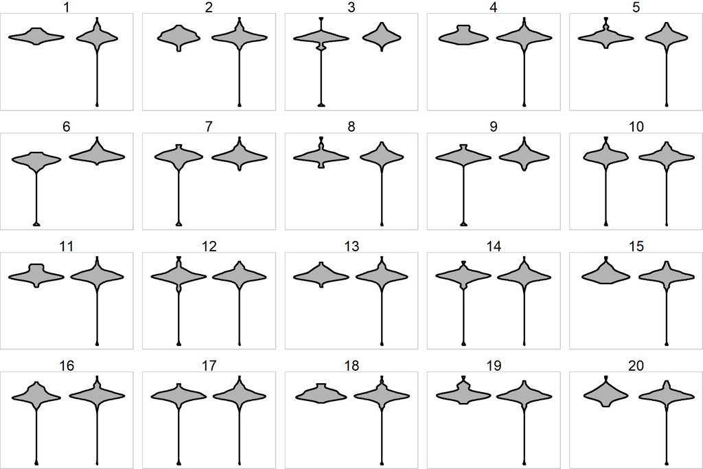

```r
# Lineup Plot for pH
set.seed(789)

pH_data <- yarra_wq_compare %>%
  filter(parameter == "pH")

lineup(
  method = null_permute("period"),
  true = pH_data,
  n = 20
) %>%
  ggplot(aes(x = period, y = value)) +
  geom_violin(fill = "gray70", color = "black") +
  facet_wrap(~ .sample, ncol = 5) +
  theme_void() +
  theme(
    plot.title = element_text(hjust = 0.5, size = 16),
    panel.border = element_rect(colour = "grey80", fill=NA))
```

```r
nullabor::pvisual(3, 10, 20)
```

```
     x simulated binom
[1,] 3     0.018 0.012
```

Therefore, we can conclude that the finding from our EDA is supported: the pH of the river at this location has become significantly more stable in recent years. The visual test confirms that the observed decrease in variability is a real feature of the data.

## Resources

The materials used for this report are:

Wickham H, Averick M, Bryan J, Chang W, McGowan LD, François R, Grolemund G, Hayes A, Henry L, Hester J, Kuhn M, Pedersen TL, Miller E, Bache SM, Müller K, Ooms J, Robinson D, Seidel DP, Spinu V, Takahashi K, Vaughan D, Wilke C, Woo K, Yutani H (2019). “Welcome to the tidyverse.” *Journal of Open Source Software*, *4*(43), 1686. [doi:10.21105/joss.01686](https://doi.org/10.21105/joss.01686).

Firke S (2024). *janitor: Simple Tools for Examining and Cleaning Dirty Data*. R package version 2.2.1, https://CRAN.R-project.org/package=janitor.

Wickham H, Hester J, Bryan J (2024). *readr: Read Rectangular Text Data*. R package version 2.1.5, https://CRAN.R-project.org/package=readr.

Garrett Grolemund, Hadley Wickham (2011). Dates and Times Made Easy with lubridate. Journal of Statistical Software, 40(3), 1-25. URL https://www.jstatsoft.org/v40/i03/.

Wickham H, Bryan J (2025). *readxl: Read Excel Files*. R package version 1.4.5, https://CRAN.R-project.org/package=readxl.

Müller K (2020). *here: A Simpler Way to Find Your Files*. R package version 1.0.1, https://CRAN.R-project.org/package=here.

Mark P. J. van der Loo, Edwin de Jonge (2021). Data Validation Infrastructure for R. Journal of Statistical Software, 97(10), 1-31. doi:10.18637/jss.v097.i10

Zhu H (2024). *kableExtra: Construct Complex Table with ‘kable’ and Pipe Syntax*. R package version 1.4.0, https://CRAN.R-project.org/package=kableExtra.

- https://g.co/gemini/share/bc38355560c8 helped to identify the official meaning of the various numerical codes in quality column of raw dataset.